# Proyecto Final

Olvera Diego

2025-10-27

**Link del video**: https://drive.google.com/file/d/13jZa64nWS1eUw7ggh3ub5jJtvYLrVAth/view?usp=sharing

# Afectaciones de la Barrera Fronteriza entre Mexico y U.S.A en la Poblacion del Oso negro americano

#### Universidad Nacional Autonóma de México

#### Facultad de Estudios Superiores Iztacala

#### Materia: Informática Ecológica

#### **Integrantes:**

- Lemus Tello Alexa Glenn
- Olvera Zarate Diego Alexis
- Trejo Zarco Gissela

#### Fecha:

27 de octubre del 2025

#### ——————————————————————————

## Introducción

- **Tema de la investigación:**

Como la barrera fronteriza entre Estados Unidos y México fue puesta sin pensar en el paso de la fauna silvestre local, causando que la población del Oso negro americano quedará fragmentada y con menos oportunidad de obtener alimento, agua y un refugio.

- **Pregunta a resolver:**

¿Cuál es el impacto poblacional visto en la especie *Ursus americanus* después de colocarse el muro fronterizo entre Mexico y Estados Unidos?

El presente análisis busca observar cómo ha cambiado la distribución del oso negro americano (*Ursus americanus*) desde la década de los setenta hasta la de los años dos mil veinte, con el propósito de determinar si las modificaciones en su rango de distribución se relacionan con la construcción y fortalecimiento del muro fronterizo entre México y Estados Unidos.

A lo largo de las últimas décadas, la expansión urbana, el cambio de uso de suelo y las políticas fronterizas han transformado significativamente los ecosistemas compartidos por ambos países. Estas alteraciones han reducido los corredores biológicos que permiten la migración y el flujo genético de diversas especies, entre ellas el oso negro americano. Por ello, analizar la variación en su distribución geográfica a lo largo del tiempo no solo permite comprender el impacto del muro fronterizo, sino también evaluar las consecuencias ecológicas y evolutivas que la fragmentación del hábitat puede generar en sus poblaciones

## Objetivos

- Observar cómo ha cambiado la distribución de Ursus americanus en el tiempo y si las barreras humanas, como el muro fronterizo, podrían estar afectando sus rutas de dispersión

## **Justificación**

El oso negro americano (*Ursus americanus*) ha habitado la zona fronteriza entre México y Estados Unidos desde hace aproximadamente tres millones de años. No obstante, durante los últimos tiempos, su población disminuyó de forma considerable debido a la caza indiscriminada, y hasta la actualidad no ha logrado una recuperación completa. Esta reducción poblacional provocó la pérdida significativa de diversidad genética dentro de la especie.

La conservación del oso negro americano resulta de gran relevancia ecológica, ya que cumple funciones esenciales en el mantenimiento de los ecosistemas, como la dispersión de semillas y la regulación de cadenas tróficas. Además, su presencia refleja el equilibrio ambiental de las zonas montañosas y boscosas que habita. Por ello, comprender y atender los factores que amenazan su supervivencia es fundamental para garantizar la conservación de la biodiversidad en las regiones fronterizas.

## **Planteamiento del problema**

En la actualidad, el *Ursus americanus* enfrenta un nuevo desafío: la fragmentación de su hábitat. Este proceso está reduciendo progresivamente sus rutas de migración naturales, como la ruta Arizona-México, la cual cuenta actualmente con una extensión de aproximadamente 580 kilómetros, y se encuentra interrumpida por una barrera fronteriza de 10 centímetros de ancho y 9 metros de altura.

Las políticas recientes del gobierno de los Estados Unidos, enfocadas en el fortalecimiento del muro fronterizo, han intensificado esta fragmentación ecológica. Dicha infraestructura no solo profundiza la separación política y económica entre ambos países, sino también la ecológica, al limitar el movimiento y la conectividad genética de múltiples especies silvestres. De acuerdo con estudios de **Sky Island Alliance** y **Wildlands Network** (Miranda, 2025), el 86% de los cruces de vida silvestre en la región se han visto afectados. Esta situación amenaza la variación genética de las poblaciones de osos negros en ambos países, lo que, a largo plazo, podría conducir a un proceso de extinción local por pérdida de diversidad genética (Torres, 2022).

## *Ursus americanus*

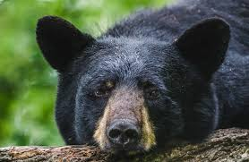

### 1. Ficha tecnica

Ficha tecnica del *Ursus americanus*

#### Nombre cientifico

*Ursus americanus*

#### Nombre comun:

Oso negro americano

#### **Filo**

Chordata

#### **Clase**

Mammalia

#### **Orden**

Carnivora

#### **Familia**

Ursidae

#### **Género**

*Ursus*

#### **Especie**

*americanus*

#### **Nombre común**

Oso negro americano

#### **Tamaño promedio**

- **Macho :** 1.4 a 2 metros
- **Hembra:** 1.2 a 1.6 metros

#### **Esperanza de vida**

Mas de 20 años

### **1.2. Comportamiento que tiene esta especie:**

Son animales solitarios con hábitos diurnos y crepusculares, sin embargo esta conducta está sujeta a la estacionalidad. En temporada de cría se pueden ver grupos de hembras donde habrá un macho dominate siendo que por ello habrá una marcada jerarquía social que será determinada por el sexo, el tamaño corporal, la fuerza y la agresividad de cada individuo.

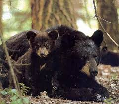

### **1.3 Importancia ecológica**

- Dispersión de semillas.
- Control de insectos
- Control de la población de algunos mamíferos pequeños y grandes.

### **1.4 Estado de conservación**

En México es considerada una especie en peligro de extinción “P” de acuerdo a la Norma Oficial Mexicana 059 desde 2002 (De Áreas Naturales Protegidas, n.d.), en Estados Unidos tiene un estado de preocupación menor “LC”, al igual que a nivel global de acuerdo a la información de Red list del 2016.

### **1.5 Localización potencial**

El *Ursus americanus* es un oso que históricamente se ha distribuido en América del norte, habitando lugares templados, semiáridos y templados en los territorios de Alaska, Canadá, 32 entidades de Estados Unidos y diversos estados al norte de México.

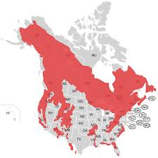

## Antecedentes

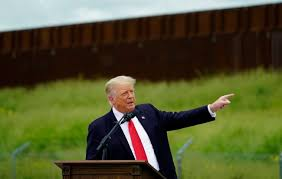

## **Librerias necesarias:**

```r
install.packages("rnaturalearthhires",
                 repos = c("https://ropensci.r-universe.dev", "https://cloud.r-project.org"))
```

```
##
##  C:\Users\52557\AppData\Local\Temp\Rtmpe0tCWZ\downloaded_packages
```

```r
library(raster) #Maneja y analiza datos espaciales en formato de cuadrículas.
```

```r
library(maps) #Dibuja mapas básicos
library(mapdata) #Proporciona mapas más detallados.
library(sp) #Trabaja con datos espaciales y vectoriales.
library(reshape2) #Reorganiza y transforma datos de formato ancho y largo.
library(mgcv) #Ajusta modelos generalizados para modelar datos complejos.
library(rgbif) #Proporciona acceso a la API del (GBIF), datos de biodiversidad
library(ggplot2) #Visualización de datos, permite generar gráficos
library(sf) #Para manejar y procesar datos geoespaciales y realizar análisis espaciales o crear mapas.
library(dplyr)# Para manipulación de datos tabulares.
library(tidyverse)#Manipulación, análisis y visualización de datos.
library(terra)#Leer, manipular y analizar grandes conjuntos de datos espaciales en formato ráster.
library(readr)#Importar datos en diferentes formatos de texto como CSV, TSV, y archivos delimitados.
library(readxl)#Paquete para leer archivos de Excel en R.
library(ggspatial)#Agregar elementos específicos de los mapas como escalas, flechas del norte, anotaciones espaciales.
library(rnaturalearth)#para cargar archivos shp de mexico
library(rnaturalearthdata)#escalas mayores
library(viridis) #para paletas de colores.
library(patchwork)#Combinar graficos en R
library(grid)# Para utilizar el objeto grob
library(gridExtra)# Paquete necesario para combinar gráficos
library(paletteer) #para paletas de colores.
library(devtools) #Simplifica y agiliza el desarrollo de paquetes R.
library(readr) #Poder leer datos rectangulares de archivos delimitados, como valores separados por comas (CSV)
library(elevatr) #Acceso a los datos de elevaciÃ³n desde las API web.
library(rnaturalearthhires)#para hacer mapas de alta resolución (escala 10)
library(ggtext)
```

## La historia del mundo fronterizo entre Estados Unidos y Mexico

El **muro fronterizo** entre los Estados Unidos y México ha sido una infraestructura clave en las políticas de seguridad y control migratorio desde la década de 1990. Su construcción comenzó bajo la administración de Bill Clinton con el **Programa de Seguridad Fronteriza**, que consistía en cercas en áreas urbanas para controlar los cruces ilegales. Posteriormente, durante la administración de George W. Bush en 2006, la Ley de Seguridad Fronteriza expandió su construcción hacia áreas rurales.

La administración de Donald Trump (2017-2021) impulsó la construcción de un muro completo, mientras que la administración de Joe Biden en 2021 pausó la expansión, aunque algunas secciones aún están en construcción.

[figure not shown]

## Linea del tiempo de la frontera

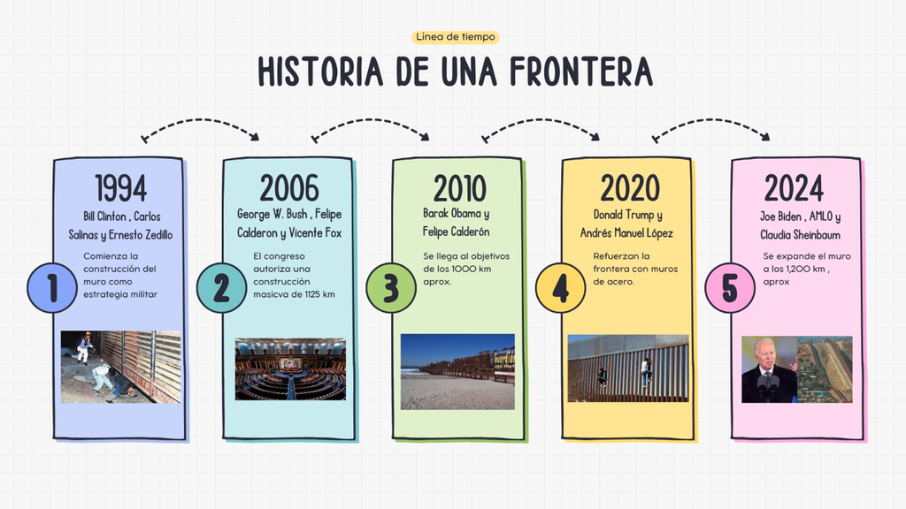

## Impacto del Muro Fronterizo sobre la Fauna: **Ursus americanus**

El **muro fronterizo** ha tenido un impacto ambiental significativo, especialmente en especies como **Ursus americanus**. Las barreras físicas han fragmentado su hábitat, limitando su capacidad para moverse entre México y los Estados Unidos. Esto ha alterado sus patrones migratorios, su acceso a fuentes de alimento y ha aislado poblaciones, afectando la diversidad genética y poniendo en riesgo su conservación a largo plazo.

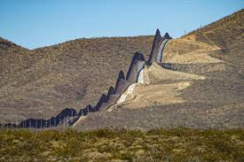

[figure not shown]

## 2. Limpieza de la base de datos

#### **2.1 Parametros de busqueda:**

```r
especie <- "Ursus americanus" #Creamos un valor llamado especie, a partir de nuestra especie.
pais1 <- "MX" #Creamos un valor llamado pais1, a partir de México (se pone con su código ISO).
pais2 <- "US" #Creamos un valor llamado pais2, a partir de Estados Unidos (se pone con su código ISO)
year_range <- c(1970, 2024) #Creamos un vector, en donde solo nos muestre
```

#### **2.2 Obtener taxonKey**

```r
taxon <- name_backbone(name = especie, rank = "species")
taxon_key <- taxon$usageKey
```

#### **2.3 Descarga de ocurrencias desde GIBFT**

```r
res_mx <- occ_search(
  taxonKey = taxon_key,
  country = pais1,
  hasCoordinate = TRUE,
  basisOfRecord = "HUMAN_OBSERVATION",
  year = paste0(year_range[1], ",", year_range[2]),
  limit = 20000
)
```

```r
res_us <- occ_search(
  taxonKey = taxon_key,
  country = pais2,
  hasCoordinate = TRUE,
  basisOfRecord = "HUMAN_OBSERVATION",
  year = paste0(year_range[1], ",", year_range[2]),
  limit = 20000
)
```

#### ***2.4 Unión de data frames**

```r
df_mx <- res_mx$data
df_us <- res_us$data

datos_ursus <- bind_rows(df_mx, df_us) %>%
  select(key, species, genus, decimalLongitude, decimalLatitude,
         year, stateProvince, country, countryCode)
```

#### **2.5 Limpieza y filtrado de datos**

```r
datos_ursus <- datos_ursus %>%
  filter(!is.na(decimalLongitude),
         !is.na(decimalLatitude),
         !is.na(year)) %>%
  distinct(key, .keep_all = TRUE) %>%
  mutate(
    year = as.integer(year),
    countryCode = toupper(countryCode)
  ) %>%
  filter(
    year >= year_range[1],
    year <= year_range[2],
    countryCode %in% c("MX", "US")
  )
```

## 3. Acomodo de los datos

#### **3.1 Agrupar por décadas**

```r
datos_ursus <- datos_ursus %>% mutate(decada = paste0(floor(year / 10) * 10, "s"))

decadas_tabla <- datos_ursus %>% group_by(country = countryCode, decada) %>% summarise(abundancia = n(), .groups = "drop")
```

#### **3.2 Completar décadas faltantes**

```r
# ---- 6. Completar décadas faltantes ----
decadas_niveles <- c("1970s", "1980s", "1990s", "2000s", "2010s", "2020s")
decadas_tabla <- decadas_tabla %>%
  complete(country = c("MX", "US"),
           decada = decadas_niveles,
           fill = list(abundancia = 0)) %>%
  mutate(decada = factor(decada, levels = decadas_niveles))
```

#### **3.3 Resultado final**

```r
print(decadas_tabla)
```

```
## # A tibble: 12 × 3
##    country decada abundancia
##    <chr>   <fct>       <int>
##  1 MX      1970s           0
##  2 MX      1980s           0
##  3 MX      1990s           0
##  4 MX      2000s          23
##  5 MX      2010s         265
##  6 MX      2020s         533
##  7 US      1970s           0
##  8 US      1980s           0
##  9 US      1990s           0
## 10 US      2000s           0
## 11 US      2010s        2981
## 12 US      2020s       17019
```

```r
datos_recientes <- datos_ursus %>%
  filter(decada %in% c("2010s", "2020s"))

#Por falta de datos del 2010 para atrás en ambos países, el proyecto se redujo de intervalos de tiempo a las decádas de los 2010´s y 2020´s.Le pedimos al paquete que solo nos de los datos de los 2010´s y los 2020´s.
```

## 4. Analisis y graficos

#### 4.1 Gráfico de Barras para ver la Abundancia del *Ursus americanus* a través de los años (México vs EEUU

```r
 ls()
```

```
##  [1] "datos_recientes" "datos_ursus"     "decadas_niveles" "decadas_tabla"
##  [5] "df_mx"           "df_us"           "especie"         "pais1"
##  [9] "pais2"           "res_mx"          "res_us"          "taxon"
## [13] "taxon_key"       "year_range"
```

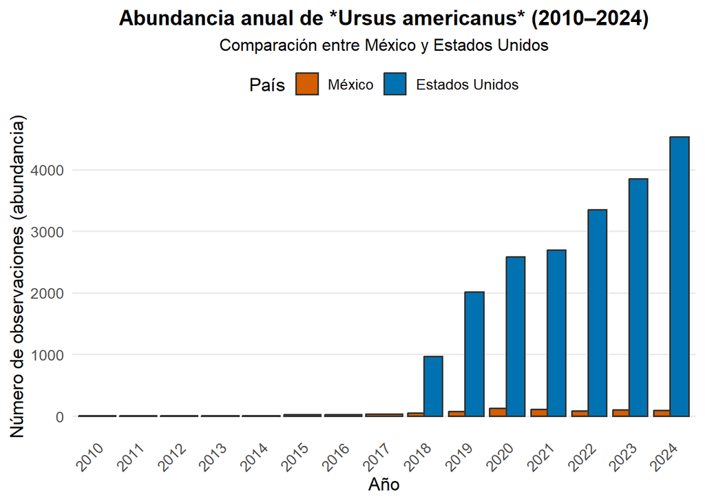

```r
abund_anual <- datos_recientes %>%
  group_by(year, countryCode) %>%
  summarise(abundancia = n(), .groups = "drop")

Grafico_Abundancia <- ggplot(abund_anual, aes(x = factor(year), y = abundancia, fill = countryCode)) +
  geom_bar(stat = "identity", position = position_dodge(width = 0.8), color = "gray20") +
  scale_fill_manual(values = c("MX" = "#D55E00", "US" = "#0072B2"),
                    labels = c("México", "Estados Unidos")) +
  theme_minimal(base_size = 13) +
  labs(
    title = "Abundancia anual de *Ursus americanus* (2010–2024)",
    subtitle = "Comparación entre México y Estados Unidos",
    x = "Año",
    y = "Número de observaciones (abundancia)",
    fill = "País"
  ) +
  theme(
    plot.title = element_text(face = "bold", size = 15, hjust = 0.5),
    plot.subtitle = element_text(size = 12, hjust = 0.5),
    axis.text.x = element_text(angle = 45, vjust = 0.9, hjust = 1),
    legend.position = "top",
    panel.grid.minor = element_blank(),
    panel.grid.major.x = element_blank()
  )

Grafico_Abundancia
```

México tiene una menor abundancia de *Ursus americanus* que en EEUU, lo cual lo podemos ver reflejado en sus estados de conservación. Además que, actualmente el *Ursus americanus* en 2024 llego en su punto más alto de abundancia de este siglo, siendo que esto puede ser debido a las ONG’s de EEUU que han trabajado de forma activa para aumentar la población de este organismo.

Por ejemplo “Defenders of wildlife” quienes con ayuda de otras ONG’s lograron sacar al oso americano de la lista de las especies amenazadas en 2012 siendo que desde ahí va ha ido aumentando su población, hasta que en 2018 consigue tener un gran incremento notorio.

- **Calcular distancia al muro (aprox. con el paralelo 31°N**)

```r
# Diferencia en latitud respecto a la frontera
# Cada grado de latitud ≈ 111 km
datos_recientes <- datos_recientes %>%
  mutate(
    dist_muro_km = (decimalLatitude - 31) * 111,
    # Norte (EE.UU.) será positivo, Sur (México) negativo
    dist_muro_km = ifelse(countryCode == "MX", -abs(dist_muro_km), abs(dist_muro_km))
  )
```

- **Agrupación por década, país y redondeo distancias**

```r
datos_dist <- datos_recientes %>%
  mutate(dist_km_redondeada = round(dist_muro_km, -1)) %>%  # redondea cada 10 km
  group_by(decada, countryCode, dist_km_redondeada) %>%
  summarise(observaciones = n(), .groups = "drop")
```

#### 4.3 Gráfico de dispersión bilateral

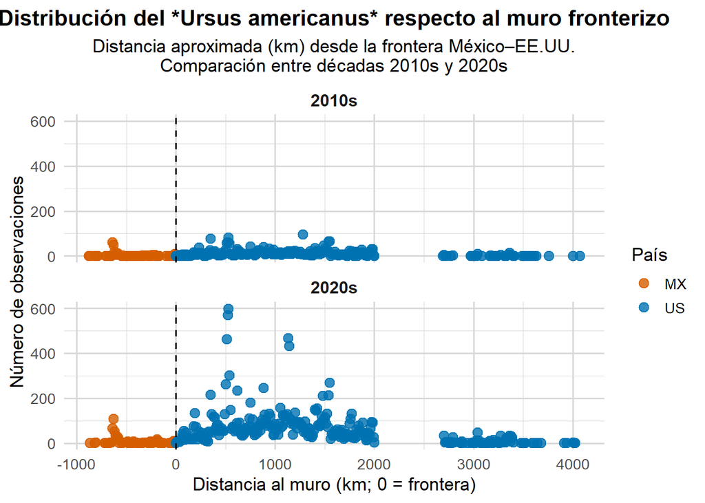

```r
Grafico_dispersion <- ggplot(datos_dist, aes(x = dist_km_redondeada, y = observaciones, color = countryCode)) +
  geom_point(size = 3, alpha = 0.8) +
  geom_vline(xintercept = 0, color = "black", linetype = "dashed") +
  scale_color_manual(values = c("MX" = "#D55E00", "US" = "#0072B2")) +
  facet_wrap(~decada, ncol = 1) +
  theme_minimal(base_size = 13) +
  labs(
    title = "Distribución del *Ursus americanus* respecto al muro fronterizo",
    subtitle = "Distancia aproximada (km) desde la frontera México–EE.UU.\nComparación entre décadas 2010s y 2020s",
    x = "Distancia al muro (km; 0 = frontera)",
    y = "Número de observaciones",
    color = "País"
  ) +
  theme(
    plot.title = element_text(face = "bold", hjust = 0.5),
    plot.subtitle = element_text(hjust = 0.5),
    strip.text = element_text(face = "bold", size = 12),
    panel.grid = element_line(color = "gray85")
  )

Grafico_dispersion
```

Este gráfico nos muestra como una parte de los osos de EEUU se niegan a moverse de su nicho, pero que conforme se alejan, podemos notar que son menos los individuos que se ven en zonas más acercadas a Canáda y Alaska.

## 5. Graficos de exploracion de los datos

#### 5.1 Gráfico de mapas comparativos en donde nos muestran la frecuencia de observaciones entre ambos países

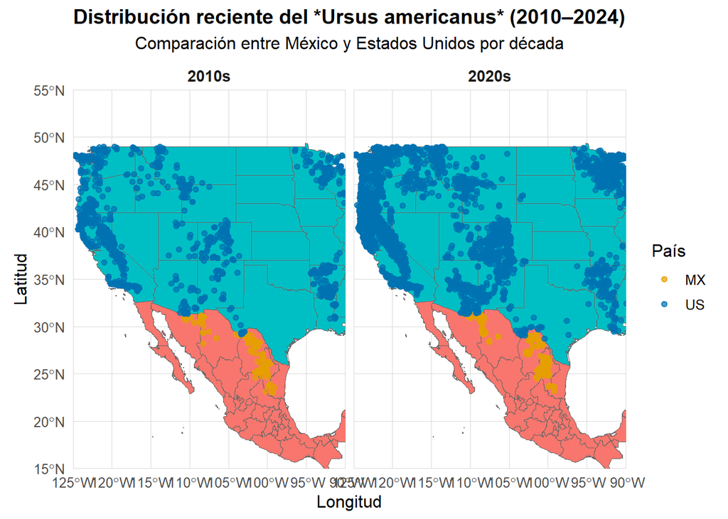

```r
mx <- ne_states(country = "Mexico", returnclass = "sf")
us <- ne_states(country = "United States of America", returnclass = "sf")
mapa_base <- rbind(mx, us) #Unimos ambos


Grafico_mapas <- ggplot() +
  geom_sf(data = mapa_base, aes(fill = admin), color = "gray40", size = 0.3, show.legend = FALSE) +
  geom_point(
    data = datos_recientes,
    aes(x = decimalLongitude, y = decimalLatitude, color = countryCode),
    size = 1.6, alpha = 0.7
  ) +
  scale_color_manual(values = c("MX" = "#E69F00", "US" = "#0072B2")) +
  coord_sf(xlim = c(-125, -90), ylim = c(15, 55), expand = FALSE) +
  facet_wrap(~decada, ncol = 2) +
  theme_minimal(base_size = 12) +
  labs(
    title = "Distribución reciente del *Ursus americanus* (2010–2024)",
    subtitle = "Comparación entre México y Estados Unidos por década",
    color = "País",
    x = "Longitud",
    y = "Latitud"
  ) +
  theme(
    strip.text = element_text(face = "bold", size = 11),
    plot.title = element_text(face = "bold", size = 14, hjust = 0.5),
    plot.subtitle = element_text(size = 12, hjust = 0.5),
    panel.grid = element_line(color = "gray85", size = 0.2)
  )
Grafico_mapas
```

#### **5.2 Gráfico de boxplots**

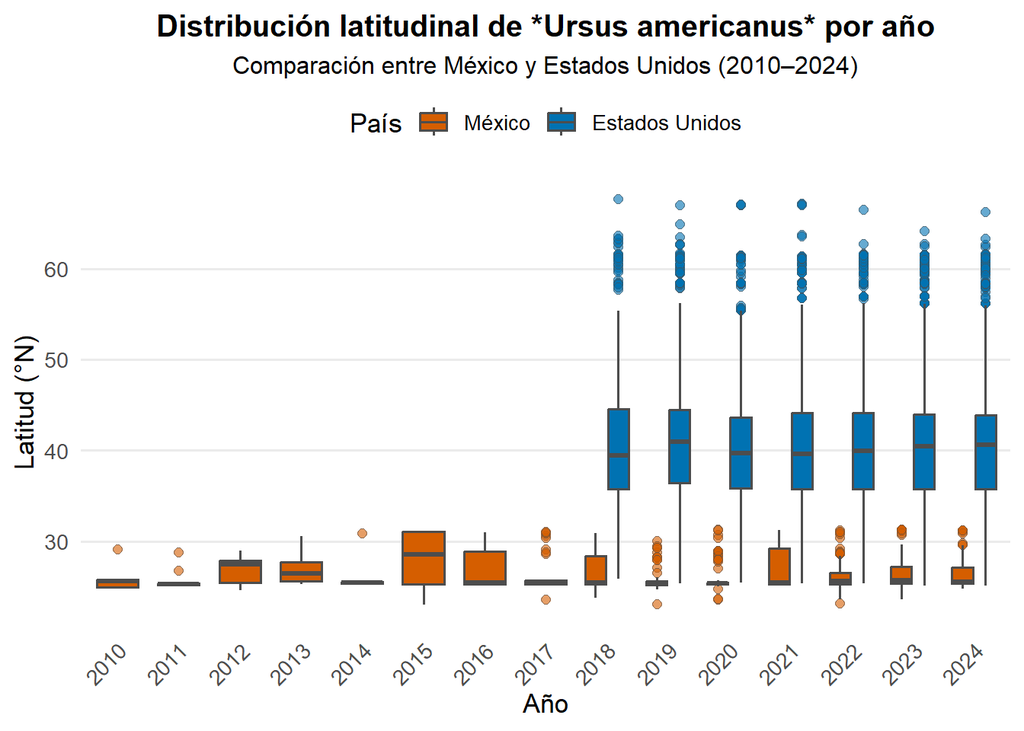

```r
Grafico_Boxplots <- ggplot(datos_recientes, aes(x = factor(year), y = decimalLatitude, fill = countryCode)) +
  geom_boxplot(outlier.shape = 21, outlier.alpha = 0.6, outlier.size = 2, color = "gray30") +
  scale_fill_manual(values = c("MX" = "#D55E00", "US" = "#0072B2"),
                    labels = c("México", "Estados Unidos")) +
  theme_minimal(base_size = 13) +
  labs(
    title = "Distribución latitudinal de *Ursus americanus* por año",
    subtitle = "Comparación entre México y Estados Unidos (2010–2024)",
    x = "Año",
    y = "Latitud (°N)",
    fill = "País"
  ) +
  theme(
    plot.title = element_text(face = "bold", size = 15, hjust = 0.5),
    plot.subtitle = element_text(size = 12, hjust = 0.5),
    axis.text.x = element_text(angle = 45, vjust = 0.9, hjust = 1),
    legend.position = "top",
    panel.grid.minor = element_blank(),
    panel.grid.major.x = element_blank()
  )
Grafico_Boxplots
```

Esta gráfica confirma la información del mapa anterior, aunque sea de forma indirecta, aunque también es importante recalcar los “falsos positivos” que puede llegar a darse en un análisis estadístico, ya que las filas de error son más frecuente en las cajas de EEUU, lo que podría ser corregido realizando más pruebas estadísticas que nos permitan manejar de mejor manera las observaciones humanas.

Situación que que en México se mantiene más estable, puede ser por falta de estudios de campo, o bien, porque hay una población territorial que no permite ingresar a nuevos individuos a su hogar.

## 6. Mapa del sitio de estudio

#### **6.1. Cargar capa raster (.tif)**

```r
raster_relieve <- terra::rast("SR_50M.tif")
print(terra::crs(raster_relieve)) ## Verifica que tenga sistema de coordenadas
```

[output not shown]

#### **6.2. Verifica que tenga el CRS correcto (WGS84)**

```r
if (terra::crs(raster_relieve) != "EPSG:4326") { raster_relieve <- terra::project(raster_relieve, "EPSG:4326") }
```

```
## |---------|---------|---------|---------|=========================================
```

#### **6.3. Capa vectorial: división política**

```r
mx <- rnaturalearth::ne_states(country = "Mexico", returnclass = "sf")
us <-rnaturalearth::ne_states(country = "United States of America", returnclass = "sf")
mapa_base <- rbind(mx, us)
```

#### **6.4 Definir zona de estudio**

```r
zona_estudio <- st_bbox(c(xmin = -120, xmax = -95, ymin = 20, ymax = 40), crs = st_crs(4326)) %>%
  st_as_sfc()
```

#### **6.5 Recortar el raster a esa zona (para hacerlo más rápido y limpio)**

```r
raster_relieve_crop <- crop(raster_relieve, vect(zona_estudio))
```

#### **6.6 Cargar tus datos de *Ursus americanus***

```r
datos_recientes <- datos_ursus %>%
  filter(decada %in% c("2010s", "2020s")) %>%
  filter(!is.na(decimalLongitude), !is.na(decimalLatitude))
```

#### **6.7 Convertir a formato espacial**

```r
puntos_ursus <- st_as_sf(datos_recientes,
                         coords = c("decimalLongitude", "decimalLatitude"),
                         crs = 4326)
```

#### **6.8 Crear el mapa**

```
## Scale on map varies by more than 10%, scale bar may be inaccurate
```

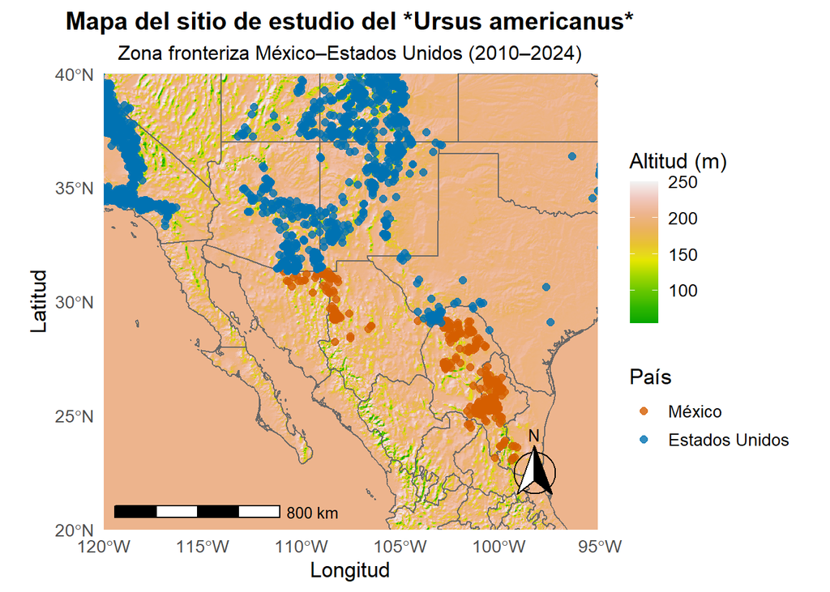

```r
raster_df <- as.data.frame(raster_relieve_crop, xy = TRUE)
names(raster_df)[3] <- "altitud"

MAPA_FINAL <- ggplot() +
  # Capa raster
  geom_raster(data = raster_df, aes(x = x, y = y, fill = altitud)) +
  scale_fill_gradientn(colours = terrain.colors(10), name = "Altitud (m)") +

  # Fronteras y divisiones políticas
  geom_sf(data = mapa_base, fill = NA, color = "gray40", size = 0.4) +

  # Puntos de Ursus
  geom_sf(data = puntos_ursus, aes(color = countryCode),
          size = 2, alpha = 0.8) +
  scale_color_manual(
    values = c("MX" = "#D55E00", "US" = "#0072B2"),
    labels = c("México", "Estados Unidos"),
    name = "País"
  ) +

  coord_sf(xlim = c(-120, -95), ylim = c(20, 40), expand = FALSE) +
  annotation_scale(location = "bl", width_hint = 0.35, text_cex = 0.8) +
  annotation_north_arrow(location = "br", which_north = "true",
                         pad_x = unit(0.6, "cm"), pad_y = unit(0.6, "cm"),
                         style = north_arrow_fancy_orienteering) +
  labs(
    title = "Mapa del sitio de estudio del *Ursus americanus*",
    subtitle = "Zona fronteriza México–Estados Unidos (2010–2024)",
    x = "Longitud",
    y = "Latitud"
  ) +
  theme_minimal(base_size = 13) +
  theme(
    legend.position = "right",
    plot.title = element_text(face = "bold", size = 15, hjust = 0.5),
    plot.subtitle = element_text(size = 12, hjust = 0.5),
    panel.grid = element_line(color = "gray85", size = 0.2)
  )

MAPA_FINAL
```

## Conclusiones:

En la comparación entre países, Estados Unidos presenta una mayor abundancia de registros, lo cual puede estar relacionado con una mayor disponibilidad de hábitat y recursos. Sin embargo, la presencia constante del oso en el norte de México evidencia igual que existe una población que es capaz de adaptarse a estos causantes antropogénicos y la importancia de los corredores biológicos transfronterizos.

Por lo que este análisis sugiere que las barreras físicas, como el muro fronterizo, podrían influir en la dispersión de la especie, limitando el flujo entre poblaciones. Por ello, resulta fundamental promover estrategias internacionales de conservación que aseguren la conectividad ecológica y la protección de su hábitat en ambos países, poniendo como importancia la creación de corredores biológicos para toda la fauna, de gran o pequeño tamaño, en la frontera México-Estados Unidos